# Workshop: Data Management & Visualization in `R` for Biology

Suppose we want to compare the width of the sepals accross species

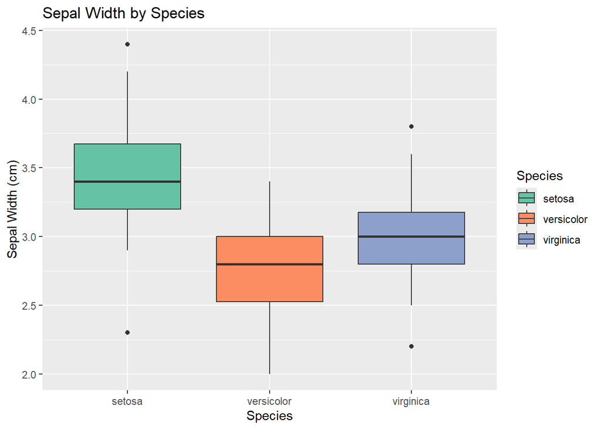

```r
ggplot(iris, aes(x = Species, y = Sepal.Width, fill = Species)) +
  geom_boxplot() +  # Boxplot
  labs(title = "Sepal Width by Species", y = "Sepal Width (cm)") +
  scale_fill_brewer(palette = "Set2")  # Color palette
```

**Line Plot (Time Series)**

Suppose we have the following data:

```r
time <- seq(0, 24, by = 2)
temperature <- c(25, 26, 28, 30, 32, 33, 34, 33, 31, 29, 27, 25, 24)
temp_data <- data.frame(time, temperature)

head(temp_data)
```

```
##   time temperature
## 1    0          25
## 2    2          26
## 3    4          28
## 4    6          30
## 5    8          32
## 6   10          33
```

We can create a line plot by:

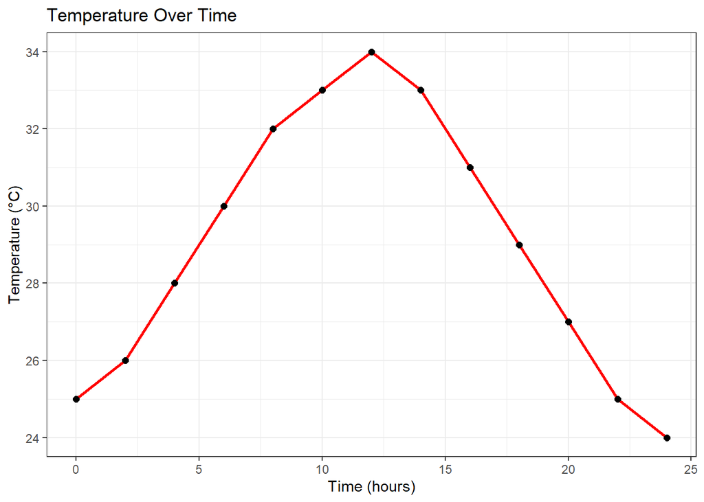

```r
ggplot(temp_data, aes(x = time, y = temperature)) +
  geom_line(color = "red", linewidth = 1) +  # Line layer
  geom_point(size = 2) +  # Points
  labs(title = "Temperature Over Time", x = "Time (hours)", y = "Temperature (°C)") +
  theme_bw()
```

**Bar Plot (Counts or Proportions)**

Suppose we want visualize the bacterial colony counts under different antibiotics given by

```r
antibiotic <- c("Ampicillin", "Streptomycin", "Control")
colonies <- c(20, 15, 50)
count_data <- data.frame(antibiotic, colonies)

head(count_data)
```

```
##     antibiotic colonies
## 1   Ampicillin       20
## 2 Streptomycin       15
## 3      Control       50
```

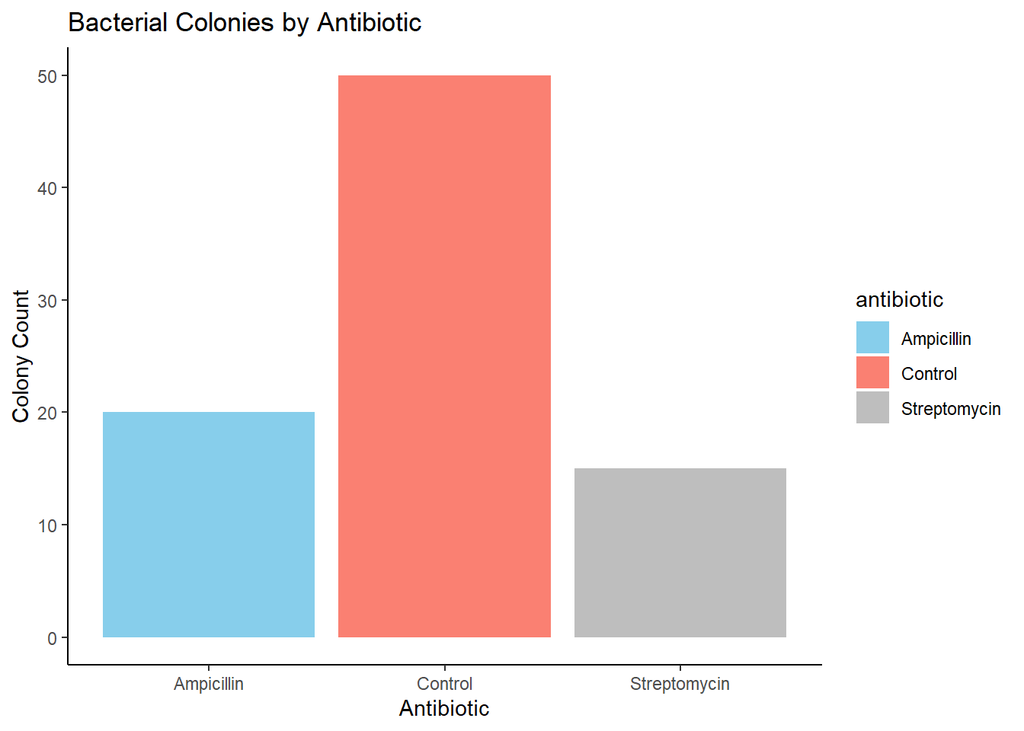

```r
ggplot(count_data, aes(x = antibiotic, y = colonies, fill = antibiotic)) +
  geom_col() +  # Bar plot
  labs(title = "Bacterial Colonies by Antibiotic", x = "Antibiotic", y = "Colony Count") +
  scale_fill_manual(values = c("skyblue", "salmon", "gray")) +
  theme_classic()
```

#### Customization

Here are some customization that we can easily apply:

1. [Themes](https://ggplot2-book.org/themes#sec-themes)
   - `theme_grey()`: the signature `ggplot2` theme with a light grey background and white gridlines.
   - `theme_bw()`: a variation on `theme_grey()` that uses a white background and thin grey grid lines.
   - `theme_linedraw()`: a theme with only black lines of various widths on white backgrounds, reminiscent of a line drawing.
   - `theme_light()`: similar to `theme_linedraw()` but with light grey lines and axes, to direct more attention towards the data.
   - `theme_dark()`: the dark cousin of `theme_light()`, with similar line sizes but a dark background. Useful to make thin coloured lines pop out.
   - `theme_minimal()`: a minimalistic theme with no background annotations.
   - `theme_classic()`: a classic-looking theme, with x and y axis lines and no gridlines.
   - `theme_void()`: a completely empty theme.
2. [Color Scales](https://ggplot2-book.org/scales-colour.html): Use colorblind-friendly palettes:
   - `scale_fill_viridis_d()`: Discrete colors
   - `scale_color_viridis_c()`: Continuous colors
3. Faceting: Split plots into panels (small multiples):

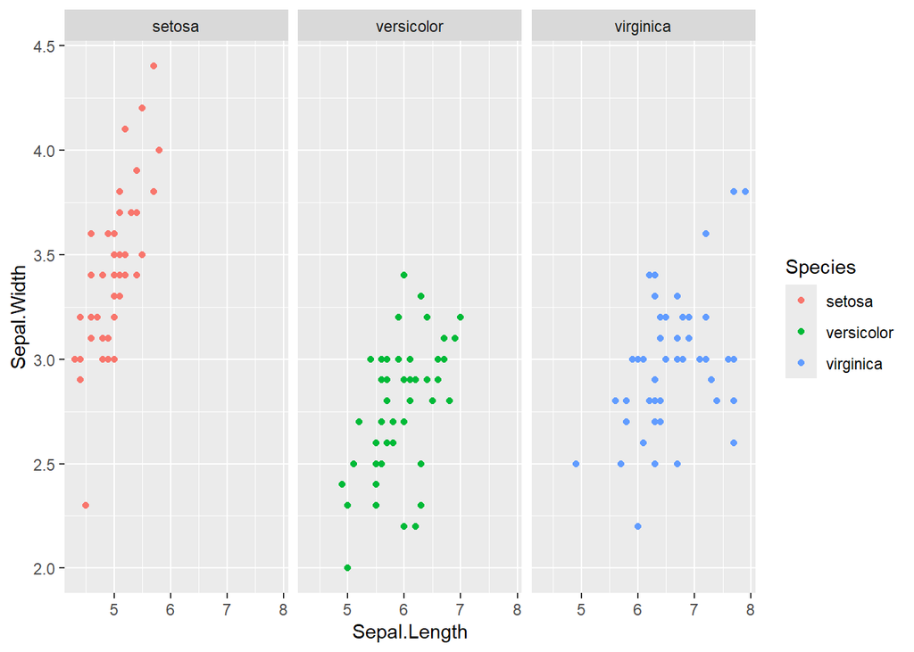

```r
ggplot(iris, aes(x = Sepal.Length, y = Sepal.Width, color = Species)) +
  geom_point() +
  facet_wrap(~Species)  # Separate panels by species
```

4. Saving Plots: Use `ggsave()` for publication-ready output

Read more about ggplot to [ggplot2: Elegant Graphics for Data Analysis (3e) by Hadley Wickham](https://ggplot2-book.org/)

#### More Examples

**Example 17**: `ggplot` version of Example 10

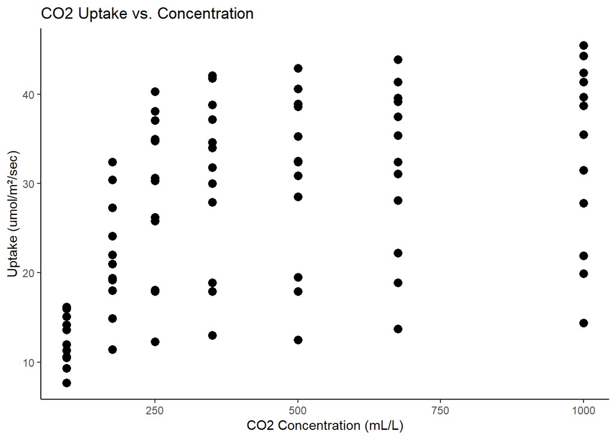

```r
co2_ggplot <- ggplot(CO2, aes(x = conc, y = uptake)) +
  geom_point(size = 3) +
  labs(title = "CO2 Uptake vs. Concentration",
       x = "CO2 Concentration (mL/L)", y = "Uptake (umol/m²/sec)") +
  theme_classic()

co2_ggplot
```

**Short Exercise:** Edit the `ggplot` object `co2_ggplot` by changing the color of points according to their `Treatment`.

```r
# write your answer here
```

**Example 18**: `ggplot` version of the histogram in Example 12

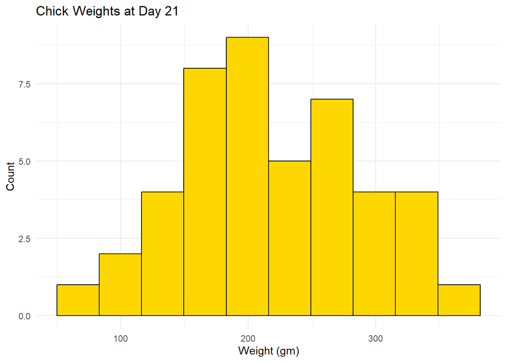

```r
final_weights_df <- ChickWeight[ChickWeight$Time == 21,]

Final_Weight_gg <- ggplot(final_weights_df, aes(x = weight)) +
  geom_histogram(bins = 10, fill = "gold", color = "black") +
  labs(title = "Chick Weights at Day 21", x = "Weight (gm)", y = "Count") +
  theme_minimal()

Final_Weight_gg
```

**Short Exercise:** Edit the `ggplot` object `Final_Weight_gg` by changing the number of bins into 15.

```r
# write your answer here
```

**Bar charts**

There are two types of bar charts: `geom_bar()` and `geom_col()`. `geom_bar()` makes the height of the bar proportional to the number of cases in each group (or if the weight aesthetic is supplied, the sum of the weights). If we want the heights of the bars to represent values in the data, we use `geom_col()` instead.`geom_bar()` uses `stat_count()` by default: it counts the number of cases at each x position. `geom_col()` uses `stat_identity()`: it leaves the data as is.

**Example 19**: Measurements of Penguins near Palmer Station, Antarctica

Data on adult penguins covering three species found on three islands in the Palmer Archipelago, Antarctica, including their size (flipper length, body mass, bill dimensions), and sex.

Suppose we want to present the distribution of penguins by species.

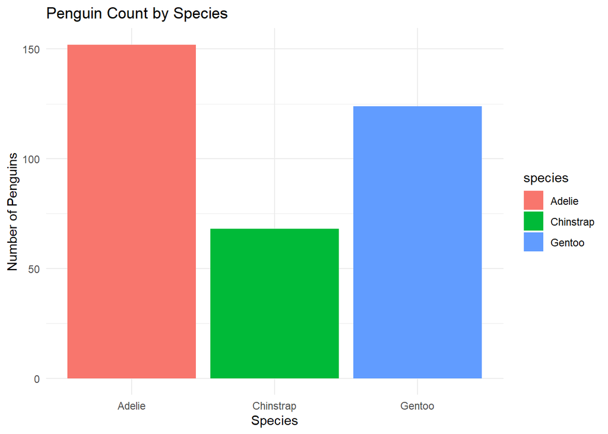

```r
ggplot(penguins, aes(x = species,fill = species)) +
  geom_bar() +
  labs(title = "Penguin Count by Species",
       x = "Species",
       y = "Number of Penguins") +
  theme_minimal()
```

We can create a horizontal bar chart by flipping the coordinate:

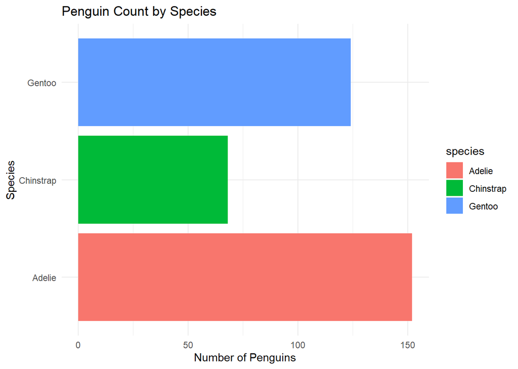

```r
ggplot(penguins, aes(x = species,fill = species)) +
  geom_bar() +
  labs(title = "Penguin Count by Species",
       x = "Species",
       y = "Number of Penguins") +
  coord_flip() +
  theme_minimal()
```

**Short Exercise:** The `geom_bar` has a parameter `position`. By setting it into `position="fill"`, we can generate proportion instead of counts. Now, generate a bar chart that shows the proportion of penguins by species.

```r
# write your answer here
```

**Example 20**: `ggplot` version of the histogram in Example 14.

Since we already have aggregated data and we want to graph the mean not the count, we can use the `geom_col` instead.

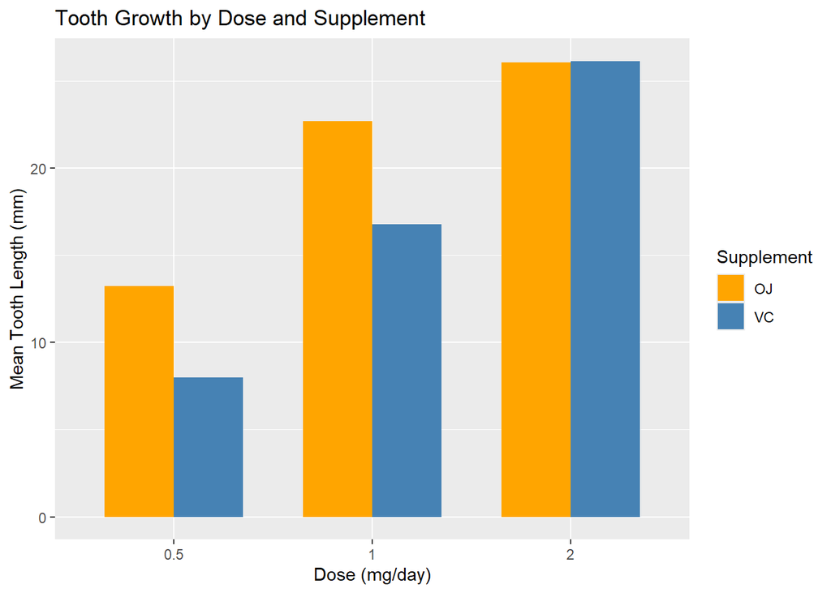

```r
# Clustered bar chart
ggplot(agg_data_TG, aes(x = factor(dose), y = len, fill = supp)) +
  geom_col(position = position_dodge(), width = 0.7) +  # Cluster bars
  labs(title = "Tooth Growth by Dose and Supplement",
       x = "Dose (mg/day)",
       y = "Mean Tooth Length (mm)",
       fill = "Supplement") +
  scale_fill_manual(values = c("orange", "steelblue"))
```

**Example 21**: `ggplot` version of the histogram in Example 15.

```r
agg_data_co2
```

```
##    Treatment        Type uptake
## 1 nonchilled      Quebec  742.0
## 2    chilled      Quebec  666.8
## 3 nonchilled Mississippi  545.0
## 4    chilled Mississippi  332.1
```

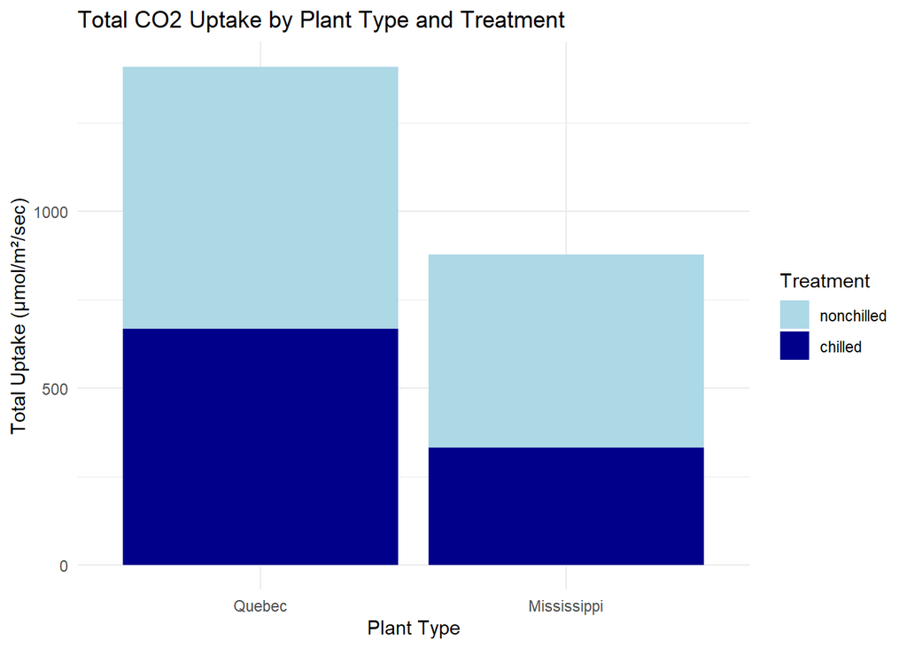

```r
ggplot(agg_data_co2, aes(x = Type, y = uptake, fill = Treatment)) +
  geom_col(position = "stack") +
  labs(title = "Total CO2 Uptake by Plant Type and Treatment",
       x = "Plant Type",
       y = "Total Uptake (μmol/m²/sec)") +
  scale_fill_manual(values = c("nonchilled" = "lightblue", "chilled" = "darkblue")) +
  theme_minimal()
```

Thus, the key differences between `geom_bar` and `geom_col` are:

| Function | Usage | When to Use |
| --- | --- | --- |
| `geom_bar()` | Count observations (`stat = "count"`) | Categorical data (e.g., species counts). |
| `geom_col()` | Use pre-computed y values (`stat = "identity"`) | Aggregated data (e.g., means, totals). |

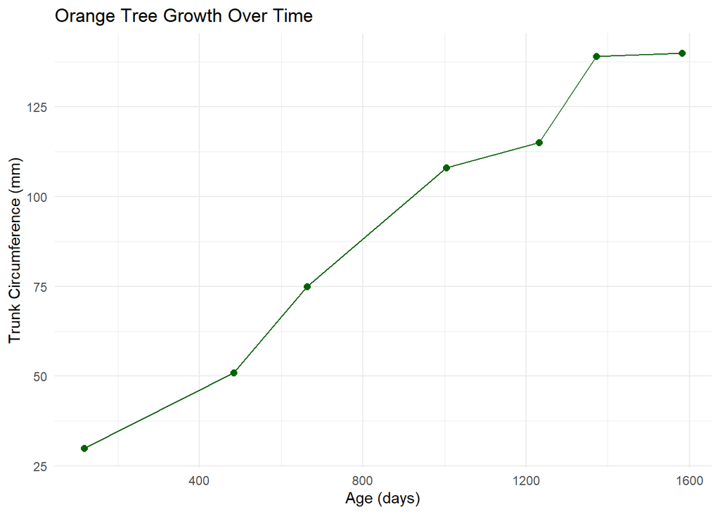

```r
ggplot(Orange3,aes(x=age,y=circumference))+
  geom_line(color="darkgreen")+ # add lines
  geom_point(color="darkgreen",size=2)+
  labs(title="Orange Tree Growth Over Time",
       x = "Age (days)",
       y = "Trunk Circumference (mm)")+
  theme_minimal()
```

**Short Exercise:** Using the original `Orange` dataset, plot the growth of the trees over time. Hint: `ae()` has parameter `group`.

```r
# write your answer here
```

## Application Exercise

[**Estimation of Obesity Levels Based On Eating Habits and Physical Condition**](https://archive.ics.uci.edu/dataset/544/estimation+of+obesity+levels+based+on+eating+habits+and+physical+condition)

This dataset include data for the estimation of obesity levels in individuals from the countries of Mexico, Peru and Colombia, based on their eating habits and physical condition. The data contains 17 attributes and 2111 records, the records are labeled with the class variable NObesity (Obesity Level), that allows classification of the data using the values of Insufficient Weight, Normal Weight, Overweight Level I, Overweight Level II, Obesity Type I, Obesity Type II and Obesity Type III. 77% of the data was generated synthetically using the Weka tool and the SMOTE filter, 23% of the data was collected directly from users through a web platform.

Reference: Estimation of Obesity Levels Based On Eating Habits and Physical Condition [Dataset]. (2019). UCI Machine Learning Repository. https://doi.org/10.24432/C5H31Z.

### Tasks

1. Import the data `ObesityDataSet_raw_and_data_sinthetic`

```r
# write your answer here
obesity_raw <- ____________________________
```

2. Print the first 3 rows of raw data

```r
head(_____,3)
```

3. Convert these columns to factors:
   - `Gender`
   - `NObeyesdad` (rename to `obesity_level`, ordered factor with levels: `c("Insufficient_Weight", "Normal_Weight", "Overweight_Level_I", "Overweight_Level_II", "Obesity_Type_I", "Obesity_Type_II", "Obesity_Type_III")`)
   - `FAVC` (labels: `c("No", "Yes")`)
4. Save the cleaned dataset as `obesity_clean.rds` in the data folder.
5. Age Distribution (Boxplot)
   1. Create a boxplot of `Age` by `obesity_level`
   2. Save as `age_distribution.png`
6. Physical Activity (Stacked Barplot)
   1. Create a stacked barplot showing `FAF` (physical activity frequency) proportions by `obesity_level`.
   2. Add legend for activity frequency levels
   3. Save as `activity_levels.png`
7. Answer the following:
   1. What trend do you observe between age and obesity level?
   2. How does physical activity frequency relate to obesity classification?